# Project: Investigate a Dataset: The Movie Database (TMDb) Analysis

- Introduction
- Data Wrangling & Cleaning
- Exploratory Data Analysis
- Conclusions

## Introduction

### Dataset Description

The data set contains information about 10,000 movies collected from The Movie Database (TMDb) such as:

> 1) id: The unique ID of the movie.  
> 2) imdb_id: The IMDB ID of the movie.  
> 3) popularity: The Popularity Score of the movie by TMDB.  
> 4) budget: The budget of the movie in dollars at its time of production.  
> 5) revenue: The total revenue of the movie in dollars after its release.  
> 6) original_title: The original title of the movie.  
> 7) cast: The names of the actors participated in the movie, contains multiple separated values.  
> 8) homepage: The official homepage of the move.  
> 9) director: The name of the movie director.  
> 10) tagline: The tagline of the movie.  
> 11) keywords: The keywords by which the movie can be found.  
> 12) overview: A brief summary of the movie.  
> 13) runtime: The runtime of the movie in minutes.  
> 14) genres: All the genres associated with the movie, contains multiple separated values.  
> 15) production_companies: Production companies involved with the movie production, contains multiple separated values.  
> 16) release_date: The release date of the movie.  
> 17) vote_count: The number of votes by users, as counted by TMDB.  
> 18) vote_average: The average rating of the movie out of 10.  
> 19) release_year: The release year of the movie.  
> 20) budget_adj: The budget of the movie in terms of 2010 dollars, accounting for inflation over time.  
> 21) revenue_adj: The total revenue of the movie in terms of 2010 dollars, accounting for inflation over time.

### Question(s) for Analysis

Here are some general questions that will be discussed along with the Analysis,

> - *Which genres are most popular from year to year?*
> - *Which year has the most produced movies? and What genres are the most produced of all time?*
> - *How the average movies runtime changed over the years?*
> - *How is the film making production changing over the years?*
> - *What are the movies with the highest Budget, Revenue and Profit?*

However, The Analysis will be focusing on the properties that are associated with movies with the highest revenues, the following topics will be discussed as well:

> - *What kinds of properties are associated with movies that have high revenues?*
> - *What is the effect of the following on the movie revenues?*

>   > *Release Date*  
>   > *Production Company*  
>   > *Director*  
>   > *Cast*  
>   > *Genres*  
>   > *Budget*  
>   > *Rating*  
>   > *Popularity*  
>   > *Runtime*

**So, Lets get started!**

```python
# Import all of the packages that will be used.
import numpy as np
import pandas as pd
pd.set_option('precision', 2)
import seaborn as sns
sns.set()
import matplotlib.pyplot as plt
plt.rcParams.update({'figure.figsize':(10,8), 'figure.dpi':100})
%matplotlib inline
```

#### Upgrade pandas to use dataframe.explode() function.

!pip install matplotlib --upgrade !pip install --upgrade pandas==0.25.0

## Data Wrangling

> In this section of the report, The data will be loaded, checked for cleanliness, and then trimmed and cleaned to be ready for analysis.

### General Properties

```python
# Loading the data and printing out a few rows
data = pd.read_csv('Database_TMDb_movie_data/tmdb-movies.csv', sep = ',')
# Making a copy to preserve the integrity of the original data
df = data.copy()
# Displaying the first rows of our data
df.head(3)
```

|  | id | imdb_id | popularity | budget | revenue | original_title | cast | homepage | director | tagline | ... | overview | runtime | genres | production_companies | release_date | vote_count | vote_average | release_year | budget_adj | revenue_adj |
| --- | --- | --- | --- | --- | --- | --- | --- | --- | --- | --- | --- | --- | --- | --- | --- | --- | --- | --- | --- | --- | --- |
| 0 | 135397 | tt0369610 | 32.99 | 150000000 | 1513528810 | Jurassic World | Chris Pratt\|Bryce Dallas Howard\|Irrfan Khan\|Vi... | http://www.jurassicworld.com/ | Colin Trevorrow | The park is open. | ... | Twenty-two years after the events of Jurassic ... | 124 | Action\|Adventure\|Science Fiction\|Thriller | Universal Studios\|Amblin Entertainment\|Legenda... | 6/9/15 | 5562 | 6.5 | 2015 | 1.38e+08 | 1.39e+09 |
| 1 | 76341 | tt1392190 | 28.42 | 150000000 | 378436354 | Mad Max: Fury Road | Tom Hardy\|Charlize Theron\|Hugh Keays-Byrne\|Nic... | http://www.madmaxmovie.com/ | George Miller | What a Lovely Day. | ... | An apocalyptic story set in the furthest reach... | 120 | Action\|Adventure\|Science Fiction\|Thriller | Village Roadshow Pictures\|Kennedy Miller Produ... | 5/13/15 | 6185 | 7.1 | 2015 | 1.38e+08 | 3.48e+08 |
| 2 | 262500 | tt2908446 | 13.11 | 110000000 | 295238201 | Insurgent | Shailene Woodley\|Theo James\|Kate Winslet\|Ansel... | http://www.thedivergentseries.movie/#insurgent | Robert Schwentke | One Choice Can Destroy You | ... | Beatrice Prior must confront her inner demons ... | 119 | Adventure\|Science Fiction\|Thriller | Summit Entertainment\|Mandeville Films\|Red Wago... | 3/18/15 | 2480 | 6.3 | 2015 | 1.01e+08 | 2.72e+08 |

3 rows × 21 columns

```python
# Displaying the last rows of our data
df.tail(3)
```

|  | id | imdb_id | popularity | budget | revenue | original_title | cast | homepage | director | tagline | ... | overview | runtime | genres | production_companies | release_date | vote_count | vote_average | release_year | budget_adj | revenue_adj |
| --- | --- | --- | --- | --- | --- | --- | --- | --- | --- | --- | --- | --- | --- | --- | --- | --- | --- | --- | --- | --- | --- |
| 10863 | 39768 | tt0060161 | 0.07 | 0 | 0 | Beregis Avtomobilya | Innokentiy Smoktunovskiy\|Oleg Efremov\|Georgi Z... | NaN | Eldar Ryazanov | NaN | ... | An insurance agent who moonlights as a carthie... | 94 | Mystery\|Comedy | Mosfilm | 1/1/66 | 11 | 6.5 | 1966 | 0.00 | 0.0 |
| 10864 | 21449 | tt0061177 | 0.06 | 0 | 0 | What's Up, Tiger Lily? | Tatsuya Mihashi\|Akiko Wakabayashi\|Mie Hama\|Joh... | NaN | Woody Allen | WOODY ALLEN STRIKES BACK! | ... | In comic Woody Allen's film debut, he took the... | 80 | Action\|Comedy | Benedict Pictures Corp. | 11/2/66 | 22 | 5.4 | 1966 | 0.00 | 0.0 |
| 10865 | 22293 | tt0060666 | 0.04 | 19000 | 0 | Manos: The Hands of Fate | Harold P. Warren\|Tom Neyman\|John Reynolds\|Dian... | NaN | Harold P. Warren | It's Shocking! It's Beyond Your Imagination! | ... | A family gets lost on the road and stumbles up... | 74 | Horror | Norm-Iris | 11/15/66 | 15 | 1.5 | 1966 | 127642.28 | 0.0 |

3 rows × 21 columns

```python
# Understanding the shape of our data
df.shape
```

```
(10866, 21)
```

The Data consists of 10866 Rows and 21 columns.

```python
# Understanding some information about our data
df.info()
```

```
<class 'pandas.core.frame.DataFrame'>
RangeIndex: 10866 entries, 0 to 10865
Data columns (total 21 columns):
id                      10866 non-null int64
imdb_id                 10856 non-null object
popularity              10866 non-null float64
budget                  10866 non-null int64
revenue                 10866 non-null int64
original_title          10866 non-null object
cast                    10790 non-null object
homepage                2936 non-null object
director                10822 non-null object
tagline                 8042 non-null object
keywords                9373 non-null object
overview                10862 non-null object
runtime                 10866 non-null int64
genres                  10843 non-null object
production_companies    9836 non-null object
release_date            10866 non-null object
vote_count              10866 non-null int64
vote_average            10866 non-null float64
release_year            10866 non-null int64
budget_adj              10866 non-null float64
revenue_adj             10866 non-null float64
dtypes: float64(4), int64(6), object(11)
memory usage: 1.7+ MB
```

Here we can observe the columns, their non-null value counts and their datatypes,  
we can see that:

> - There are some columns that are irrelevant to the analysis that will be dropped later on such as: [imdb_id, homepage, tagline, keywords, overview] as they are either containing text only or have a lot of missing values.
> - Also [budget, revenue] columns will be dropped later on as we have the adjusted budget and revenue columns.
> - [release_date] column is assigned a wrong datatype, it will be changed later on to datetime datatype.
> - There are some missing values in the [cast, director, genres, production_companies] columns which i will leave as it is for now. Also, some of these columns contain multiple values separated by (|) character which we will deal with later on.

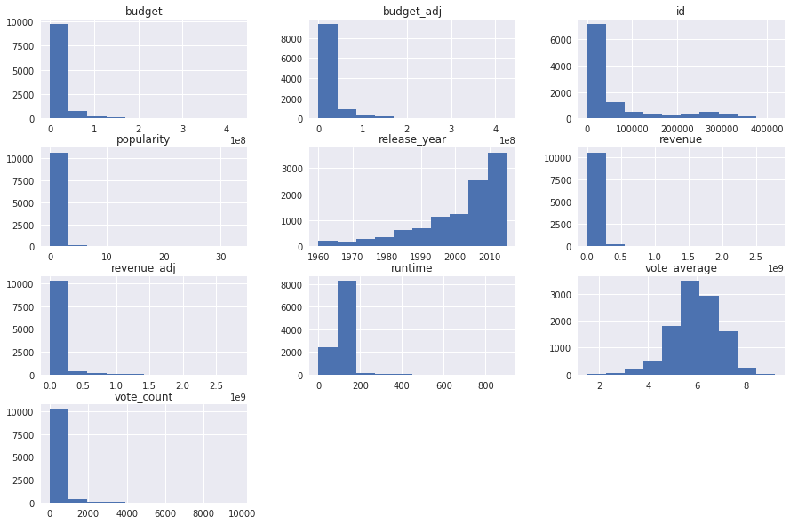

```python
# Understanding some statistical information about our data
df.hist(figsize=(15,10));
```

```python
# Understanding some statistical information about our data
df.describe()
```

|  | id | popularity | budget | revenue | runtime | vote_count | vote_average | release_year | budget_adj | revenue_adj |
| --- | --- | --- | --- | --- | --- | --- | --- | --- | --- | --- |
| count | 10866.00 | 1.09e+04 | 1.09e+04 | 1.09e+04 | 10866.00 | 10866.00 | 10866.00 | 10866.00 | 1.09e+04 | 1.09e+04 |
| mean | 66064.18 | 6.46e-01 | 1.46e+07 | 3.98e+07 | 102.07 | 217.39 | 5.97 | 2001.32 | 1.76e+07 | 5.14e+07 |
| std | 92130.14 | 1.00e+00 | 3.09e+07 | 1.17e+08 | 31.38 | 575.62 | 0.94 | 12.81 | 3.43e+07 | 1.45e+08 |
| min | 5.00 | 6.50e-05 | 0.00e+00 | 0.00e+00 | 0.00 | 10.00 | 1.50 | 1960.00 | 0.00e+00 | 0.00e+00 |
| 25% | 10596.25 | 2.08e-01 | 0.00e+00 | 0.00e+00 | 90.00 | 17.00 | 5.40 | 1995.00 | 0.00e+00 | 0.00e+00 |
| 50% | 20669.00 | 3.84e-01 | 0.00e+00 | 0.00e+00 | 99.00 | 38.00 | 6.00 | 2006.00 | 0.00e+00 | 0.00e+00 |
| 75% | 75610.00 | 7.14e-01 | 1.50e+07 | 2.40e+07 | 111.00 | 145.75 | 6.60 | 2011.00 | 2.09e+07 | 3.37e+07 |
| max | 417859.00 | 3.30e+01 | 4.25e+08 | 2.78e+09 | 900.00 | 9767.00 | 9.20 | 2015.00 | 4.25e+08 | 2.83e+09 |

Here we can observe some statistical info about the data such as the mean and 5-number summary, we can see that:

> - I'm not sure how the popularity column values are calulated or what criteria it is based on.
> - [budget_adj, revenue_adj] columns have a lot of zero values (over 50% !) which we will deal with later on.
> - We have movies from years 1960 to 2015 with the majority in the 20's period based on the release year column.
> - The movie rating is out of 10 based on votes and its ranging between 1.5 (lowest) to 9.2 (highest) with an average around 6.0
> - The runtime is an interesting one as there are movies with missing runtime which we will deal with later on. However, there are movies that reaches around 900 min! (15 hrs) in runtime which might be incorrect entries or outliers.
> - There are movies with a very low voting counts; 10 Votes only!

```python
# Checking Null values
df.isnull().sum()
```

```
id                         0
imdb_id                   10
popularity                 0
budget                     0
revenue                    0
original_title             0
cast                      76
homepage                7930
director                  44
tagline                 2824
keywords                1493
overview                   4
runtime                    0
genres                    23
production_companies    1030
release_date               0
vote_count                 0
vote_average               0
release_year               0
budget_adj                 0
revenue_adj                0
dtype: int64
```

Null values will be dealt with later on as mentioned above.

```python
# Checking duplicated values
df.duplicated().sum()
```

```
1
```

```python
# Checking the duplicated row
df[df.duplicated()]
```

|  | id | imdb_id | popularity | budget | revenue | original_title | cast | homepage | director | tagline | ... | overview | runtime | genres | production_companies | release_date | vote_count | vote_average | release_year | budget_adj | revenue_adj |
| --- | --- | --- | --- | --- | --- | --- | --- | --- | --- | --- | --- | --- | --- | --- | --- | --- | --- | --- | --- | --- | --- |
| 2090 | 42194 | tt0411951 | 0.6 | 30000000 | 967000 | TEKKEN | Jon Foo\|Kelly Overton\|Cary-Hiroyuki Tagawa\|Ian... | NaN | Dwight H. Little | Survival is no game | ... | In the year of 2039, after World Wars destroy ... | 92 | Crime\|Drama\|Action\|Thriller\|Science Fiction | Namco\|Light Song Films | 3/20/10 | 110 | 5.0 | 2010 | 3.00e+07 | 967000.0 |

1 rows × 21 columns

We have only one duplicated row which will be removed later on.

```python
# Checking unique values in our data columns
df.nunique()
```

```
id                      10865
imdb_id                 10855
popularity              10814
budget                    557
revenue                  4702
original_title          10571
cast                    10719
homepage                 2896
director                 5067
tagline                  7997
keywords                 8804
overview                10847
runtime                   247
genres                   2039
production_companies     7445
release_date             5909
vote_count               1289
vote_average               72
release_year               56
budget_adj               2614
revenue_adj              4840
dtype: int64
```

We can see that each column has a lot of unique values, The [release_year] column has 56 unique values as we mentioned previously that our dataset contains movies from years 1960 to 2015. so, no surprise there! Also, Don't forget the [cast, director, genres, production_companies] columns we will re-visit later on once cleaned as each column contains multiple values!

### Data Cleaning

> After discussing the structure of the data and any problems that need to be cleaned, In this section of the report, The data will be manipulated, trimmed and cleaned to be ready for analysis.

```python
# Dropping irrelevant columns and Displaying the first rows of our data
df.drop(columns= ['imdb_id', 'budget', 'revenue', 'homepage',
                   'tagline', 'keywords', 'overview'], axis= 1, inplace= True)
df.head(3)
```

|  | id | popularity | original_title | cast | director | runtime | genres | production_companies | release_date | vote_count | vote_average | release_year | budget_adj | revenue_adj |
| --- | --- | --- | --- | --- | --- | --- | --- | --- | --- | --- | --- | --- | --- | --- |
| 0 | 135397 | 32.99 | Jurassic World | Chris Pratt\|Bryce Dallas Howard\|Irrfan Khan\|Vi... | Colin Trevorrow | 124 | Action\|Adventure\|Science Fiction\|Thriller | Universal Studios\|Amblin Entertainment\|Legenda... | 6/9/15 | 5562 | 6.5 | 2015 | 1.38e+08 | 1.39e+09 |
| 1 | 76341 | 28.42 | Mad Max: Fury Road | Tom Hardy\|Charlize Theron\|Hugh Keays-Byrne\|Nic... | George Miller | 120 | Action\|Adventure\|Science Fiction\|Thriller | Village Roadshow Pictures\|Kennedy Miller Produ... | 5/13/15 | 6185 | 7.1 | 2015 | 1.38e+08 | 3.48e+08 |
| 2 | 262500 | 13.11 | Insurgent | Shailene Woodley\|Theo James\|Kate Winslet\|Ansel... | Robert Schwentke | 119 | Adventure\|Science Fiction\|Thriller | Summit Entertainment\|Mandeville Films\|Red Wago... | 3/18/15 | 2480 | 6.3 | 2015 | 1.01e+08 | 2.72e+08 |

```python
# Removing Duplicated values
df.drop_duplicates(inplace= True)
```

```python
# Checking that duplicated values are removed
df.duplicated().sum()
```

```
0
```

```python
# Adjusting datatypes for the release date column
df['release_date'] = pd.to_datetime(df['release_date'])
```

```python
# Creating new columns for release month and release day
df['release_month'] = df['release_date'].dt.month_name()
df['release_day'] = df['release_date'].dt.day_name()
```

```python
# Dropping release year column as it is no longer needed and Displaying the first rows of our data
df.drop(columns='release_date', axis=1, inplace=True)
df.head(3)
```

|  | id | popularity | original_title | cast | director | runtime | genres | production_companies | vote_count | vote_average | release_year | budget_adj | revenue_adj | release_month | release_day |
| --- | --- | --- | --- | --- | --- | --- | --- | --- | --- | --- | --- | --- | --- | --- | --- |
| 0 | 135397 | 32.99 | Jurassic World | Chris Pratt\|Bryce Dallas Howard\|Irrfan Khan\|Vi... | Colin Trevorrow | 124 | Action\|Adventure\|Science Fiction\|Thriller | Universal Studios\|Amblin Entertainment\|Legenda... | 5562 | 6.5 | 2015 | 1.38e+08 | 1.39e+09 | June | Tuesday |
| 1 | 76341 | 28.42 | Mad Max: Fury Road | Tom Hardy\|Charlize Theron\|Hugh Keays-Byrne\|Nic... | George Miller | 120 | Action\|Adventure\|Science Fiction\|Thriller | Village Roadshow Pictures\|Kennedy Miller Produ... | 6185 | 7.1 | 2015 | 1.38e+08 | 3.48e+08 | May | Wednesday |
| 2 | 262500 | 13.11 | Insurgent | Shailene Woodley\|Theo James\|Kate Winslet\|Ansel... | Robert Schwentke | 119 | Adventure\|Science Fiction\|Thriller | Summit Entertainment\|Mandeville Films\|Red Wago... | 2480 | 6.3 | 2015 | 1.01e+08 | 2.72e+08 | March | Wednesday |

Now, Let's try dealing with the zero values in the budget and revenue column.

> - The approach i'm taking here is that the zero values will be replaced by the mean value for each column. As mentioned previously, more than 50% of the revenue column contains a zero value, However, we will focus in our analysis on the properties of movies with the highest revenues only.

```python
# Adjusting the budget and revenue columns to be displayed in millions of dollars and re-naming
df['budget_adj'] = df['budget_adj'] / 1000000
df['revenue_adj'] = df['revenue_adj'] / 1000000
df.rename(columns= {'budget_adj': 'budget_mil',
                    'revenue_adj': 'revenue_mil'}, inplace= True)
```

```python
# Checking the counts of zero values in the budget and revenue columns
(df.query('budget_mil == 0')['budget_mil'].count(),
df.query('revenue_mil == 0')['revenue_mil'].count())
```

```
(5696, 6016)
```

```python
# Replacing the zero values in the budget and revenue columns with nan values so that the mean is not affected
df['budget_mil'].replace(0, np.nan, inplace=True)
df['revenue_mil'].replace(0, np.nan, inplace=True)
```

```python
# Calculating the mean
budget_m, revenue_m = np.nanmean(df['budget_mil']).round(2), np.nanmean(df['revenue_mil']).round(2)
budget_m, revenue_m
```

```
(36.89, 115.1)
```

```python
# Replacing the nan values in the budget and revenue columns with the calculated mean
df['budget_mil'].replace(np.nan, budget_m, inplace=True)
df['revenue_mil'].replace(np.nan, revenue_m, inplace=True)
```

```python
# Checking that the zero values are replaced in the budget and revenue columns
(df.query('budget_mil == 0')['budget_mil'].count(),
df.query('revenue_mil == 0')['revenue_mil'].count())
```

```
(0, 0)
```

```python
# Creating new column for each movie profit (revenue - budget) and Displaying the first rows of our data
df['profit_mil'] = df['revenue_mil'] - df['budget_mil']
df.head(3)
```

|  | id | popularity | original_title | cast | director | runtime | genres | production_companies | vote_count | vote_average | release_year | budget_mil | revenue_mil | release_month | release_day | profit_mil |
| --- | --- | --- | --- | --- | --- | --- | --- | --- | --- | --- | --- | --- | --- | --- | --- | --- |
| 0 | 135397 | 32.99 | Jurassic World | Chris Pratt\|Bryce Dallas Howard\|Irrfan Khan\|Vi... | Colin Trevorrow | 124 | Action\|Adventure\|Science Fiction\|Thriller | Universal Studios\|Amblin Entertainment\|Legenda... | 5562 | 6.5 | 2015 | 138.0 | 1392.45 | June | Tuesday | 1254.45 |
| 1 | 76341 | 28.42 | Mad Max: Fury Road | Tom Hardy\|Charlize Theron\|Hugh Keays-Byrne\|Nic... | George Miller | 120 | Action\|Adventure\|Science Fiction\|Thriller | Village Roadshow Pictures\|Kennedy Miller Produ... | 6185 | 7.1 | 2015 | 138.0 | 348.16 | May | Wednesday | 210.16 |
| 2 | 262500 | 13.11 | Insurgent | Shailene Woodley\|Theo James\|Kate Winslet\|Ansel... | Robert Schwentke | 119 | Adventure\|Science Fiction\|Thriller | Summit Entertainment\|Mandeville Films\|Red Wago... | 2480 | 6.3 | 2015 | 101.2 | 271.62 | March | Wednesday | 170.42 |

Alright! Now our data is trimmed and cleaned.  
We will now re-visit some information about our cleaned dataset.

```python
# Understanding the shape of our data
df.shape
```

```
(10865, 16)
```

The Data now consists of 10865 Rows and 16 columns after cleaning and removing duplicates.

```python
# Understanding some information about our data
df.info()
```

```
<class 'pandas.core.frame.DataFrame'>
Int64Index: 10865 entries, 0 to 10865
Data columns (total 16 columns):
id                      10865 non-null int64
popularity              10865 non-null float64
original_title          10865 non-null object
cast                    10789 non-null object
director                10821 non-null object
runtime                 10865 non-null int64
genres                  10842 non-null object
production_companies    9835 non-null object
vote_count              10865 non-null int64
vote_average            10865 non-null float64
release_year            10865 non-null int64
budget_mil              10865 non-null float64
revenue_mil             10865 non-null float64
release_month           10865 non-null object
release_day             10865 non-null object
profit_mil              10865 non-null float64
dtypes: float64(5), int64(4), object(7)
memory usage: 1.4+ MB
```

Here we can observe the columns, their non-null value counts and their datatypes,  
we can now see that:

> - There is now only columns that are needed for the analysis.
> - All columns are assigned a suitable datatype.
> - There are still some missing values in the [cast, director, genres, production_companies] columns which i will leave as it is as it doesn't affect our analysis. Also, some of these columns contain multiple values separated by (|) character in each row that will be separated once we need them in any further analysis.

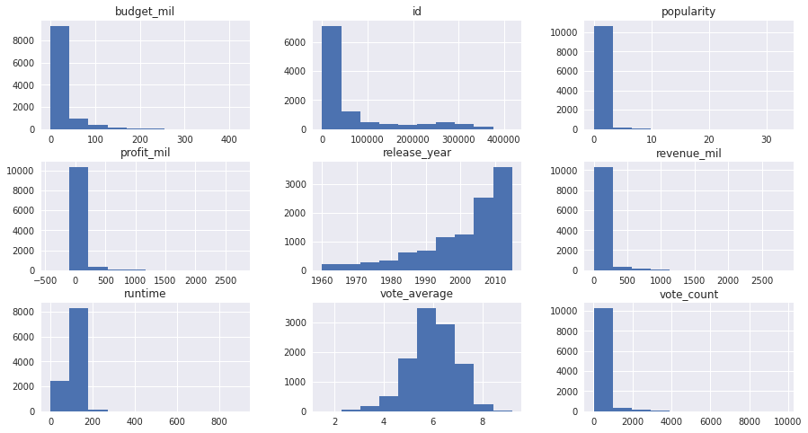

```python
# Understanding some statistical information about our data
df.hist(figsize= (15, 8));
```

```python
# Understanding some statistical information about our data
df.describe()
```

|  | id | popularity | runtime | vote_count | vote_average | release_year | budget_mil | revenue_mil | profit_mil |
| --- | --- | --- | --- | --- | --- | --- | --- | --- | --- |
| count | 10865.00 | 1.09e+04 | 10865.00 | 10865.00 | 10865.00 | 10865.00 | 1.09e+04 | 1.09e+04 | 10865.00 |
| mean | 66066.37 | 6.46e-01 | 102.07 | 217.40 | 5.98 | 2001.32 | 3.69e+01 | 1.15e+02 | 78.21 |
| std | 92134.09 | 1.00e+00 | 31.38 | 575.64 | 0.94 | 12.81 | 2.89e+01 | 1.33e+02 | 120.21 |
| min | 5.00 | 6.50e-05 | 0.00 | 10.00 | 1.50 | 1960.00 | 9.21e-07 | 2.37e-06 | -413.91 |
| 25% | 10596.00 | 2.08e-01 | 90.00 | 17.00 | 5.40 | 1995.00 | 2.46e+01 | 5.88e+01 | 23.67 |
| 50% | 20662.00 | 3.84e-01 | 99.00 | 38.00 | 6.00 | 2006.00 | 3.69e+01 | 1.15e+02 | 78.21 |
| 75% | 75612.00 | 7.14e-01 | 111.00 | 146.00 | 6.60 | 2011.00 | 3.69e+01 | 1.15e+02 | 78.21 |
| max | 417859.00 | 3.30e+01 | 900.00 | 9767.00 | 9.20 | 2015.00 | 4.25e+02 | 2.83e+03 | 2750.14 |

Here we can observe some statistical info about the data such as the mean and 5-number summary, we can now see that:

> - The zeros in the [budget_mil, revenue_mil] columns are now dealt with and replaced by the mean for each column. Much better!

## Exploratory Data Analysis

> In this section of the report, Now After the data is trimmed and cleaned, we are ready to move on to exploration. Lets Start Exploring!

### Q1: Which genres are most popular from year to year?

```python
# define a new function 'Split_Values'
def Split_Values(df, *cols):
    '''
    Split the values separated by ('|') in a column and Create a new DataFrame.
    Args:
        df - Pandas DataFrame containing the data.
        (str) *cols - All columns needed to construct the new DataFrame.
                (Note that the first value shall be the column to be splitted)
    Returns:
        df_split - DataFrame with the splitted values.
    '''
    split_cols=['id']
    split_cols.extend(cols)
    df_split = df.groupby(split_cols).count().reset_index()
    df_split[cols[0]] = df_split[cols[0]].str.split('|')
    df_split = df_split.explode(cols[0])
    return df_split
```

```python
# Using our created function to split the movies genres values
df_pop_genre = Split_Values(df, 'genres', 'popularity', 'release_year')
df_pop_genre.head()
```

|  | id | genres | popularity | release_year | original_title | cast | director | runtime | production_companies | vote_count | vote_average | budget_mil | revenue_mil | release_month | release_day | profit_mil |
| --- | --- | --- | --- | --- | --- | --- | --- | --- | --- | --- | --- | --- | --- | --- | --- | --- |
| 0 | 5 | Comedy | 1.23 | 1995 | 1 | 1 | 1 | 1 | 1 | 1 | 1 | 1 | 1 | 1 | 1 | 1 |
| 1 | 6 | Action | 0.82 | 1993 | 1 | 1 | 1 | 1 | 1 | 1 | 1 | 1 | 1 | 1 | 1 | 1 |
| 1 | 6 | Thriller | 0.82 | 1993 | 1 | 1 | 1 | 1 | 1 | 1 | 1 | 1 | 1 | 1 | 1 | 1 |
| 1 | 6 | Crime | 0.82 | 1993 | 1 | 1 | 1 | 1 | 1 | 1 | 1 | 1 | 1 | 1 | 1 | 1 |
| 2 | 11 | Adventure | 12.04 | 1977 | 1 | 1 | 1 | 1 | 1 | 1 | 1 | 1 | 1 | 1 | 1 | 1 |

```python
# Checking how many unique genres our movies feature
df_pop_genre.nunique().genres
```

```
20
```

```python
# Displaying all unique genres our movies feature
df_pop_genre.genres.unique()
```

```
array(['Comedy', 'Action', 'Thriller', 'Crime', 'Adventure',
       'Science Fiction', 'Animation', 'Family', 'Drama', 'Romance',
       'Music', 'Horror', 'Mystery', 'Fantasy', 'Documentary', 'War',
       'Western', 'History', 'Foreign', 'TV Movie'], dtype=object)
```

[figure not shown]

```python
# Plotting genres which are popular in each year
fig, axs = plt.subplots(19, 3, figsize=(15, 73))
fig.tight_layout(h_pad= 4, w_pad= 7)
i=0
j=0
for year in sorted(df_pop_genre.release_year.unique()):
    pop = df_pop_genre[df_pop_genre.release_year == year].groupby('genres')['popularity'].sum().sort_values()
    axs[i,j].barh(width= pop.values, y= pop.index)
    axs[i,j].set_title('Popular Genres in {}'.format(year))
    axs[i,j].set_xlabel('Popularity')
    axs[i,j].set_ylabel('Genres')
    j+=1
    if j%3==0:
        i+=1
        j=0
plt.show()
```

```python
# Calculating the most popular Genres of all time
all_time_pop = df_pop_genre.groupby('genres')['popularity'].sum().sort_values(ascending= False)
all_time_pop
```

```
genres
Drama              2815.52
Comedy             2247.76
Action             2208.24
Thriller           2155.72
Adventure          1697.92
Science Fiction    1230.90
Romance            1013.64
Crime              1008.64
Family              968.39
Fantasy             909.44
Horror              761.79
Animation           595.67
Mystery             558.91
Music               198.83
War                 196.47
History             192.36
Western              97.45
Documentary          94.34
TV Movie             45.24
Foreign              36.00
Name: popularity, dtype: float64
```

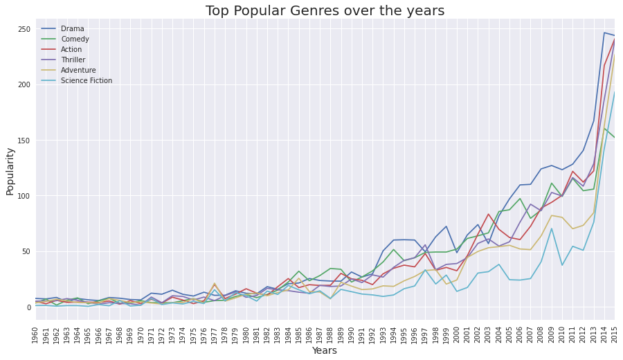

```python
# Plotting the most popular genres popularity change over the years
for genre in all_time_pop.index[:6]:
    df_pop_genre[df_pop_genre.genres == genre].groupby('release_year')['popularity'].sum().plot(figsize= (15,8))
    plt.title('Top Popular Genres over the years', fontsize= 20)
    plt.xlabel('Years', fontsize= 14)
    plt.ylabel('Popularity', fontsize= 14)
    plt.xticks(sorted(df_pop_genre.release_year.unique()), rotation= 90)
    plt.legend(all_time_pop.index)
plt.show()
```

From the previous analysis and visualizations we can conclude the following:

> - Popularity of different genres is increasing over time in general, However, the top popular genres for each year are nearly the same; people tend to prefer Drama, Comedy, Action, Thriller, and Adventure.
> - Drama is the most popular genre of all time followed by Comedy, Action and Thriller.

### Q2: What year has the most produced movies? and What genres are the most produced of all time?

```python
# Calculating the number of movies produced in each year
df_pop_genre.groupby(['release_year'])['id'].count().sort_values(ascending= False)
```

```
release_year
2014    1470
2015    1386
2013    1383
2009    1358
2011    1278
2012    1275
2008    1239
2010    1211
2007    1126
2006    1044
2005     935
2004     791
2003     738
2002     734
```

[output cut: 43 more lines]

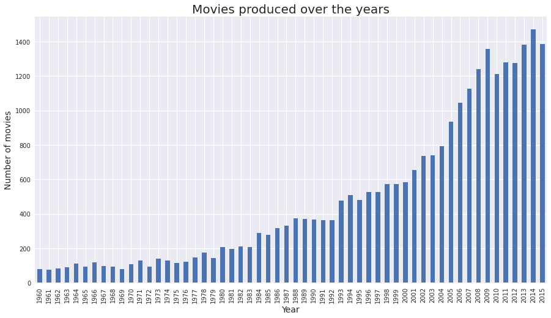

```python
# Plotting the number of movies produced over the years
df_pop_genre.groupby(['release_year'])['id'].count().plot(kind='bar', figsize= (15,8));
plt.title('Movies produced over the years', fontsize= 20)
plt.xlabel('Year', fontsize= 14)
plt.ylabel('Number of movies', fontsize= 14)
plt.show()
```

```python
# Calculating the most produced Genres of all time
df_pop_genre.genres.value_counts().sort_values(ascending=False)
```

```
Drama              4760
Comedy             3793
Thriller           2907
Action             2384
Romance            1712
Horror             1637
Adventure          1471
Crime              1354
Family             1231
Science Fiction    1229
Fantasy             916
Mystery             810
Animation           699
Documentary         520
Music               408
History             334
War                 270
Foreign             188
TV Movie            167
Western             165
Name: genres, dtype: int64
```

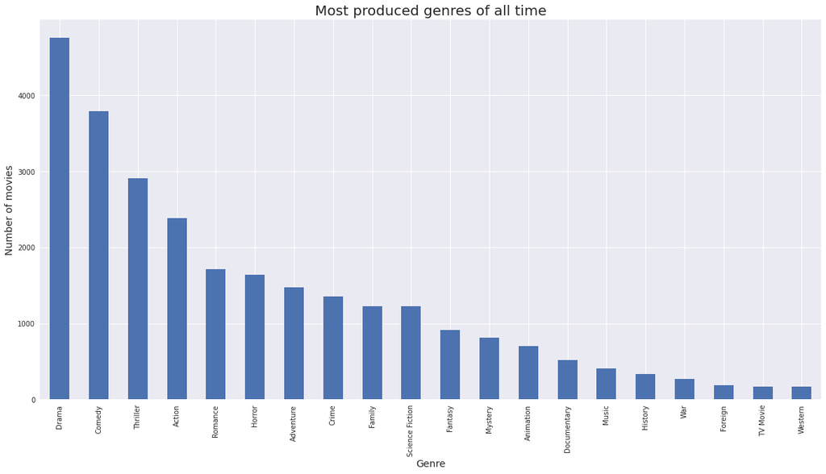

```python
# Plotting the most produced genres of all time
df_pop_genre.genres.value_counts().sort_values(ascending=False).plot(kind='bar', figsize=(20,10));
plt.title('Most produced genres of all time', fontsize= 20)
plt.xlabel('Genre', fontsize= 14)
plt.ylabel('Number of movies', fontsize= 14)
plt.show()
```

From the previous analysis and visualizations we can conclude the following:

> - Different Movies production is increasing over time in general, However, the most produced movies in total was in 2014, followed by 2015, 2013 and 2009.
> - Drama is the most produced genre of all time followed by Comedy, Thriller and Action.

### Q3: How does the movies runtime change over the years?

```python
# Calculating the average movie runtime in each year
df.groupby('release_year')['runtime'].mean().sort_values(ascending= False)
```

```
release_year
1962    124.34
1961    119.42
1965    118.17
1985    114.34
1970    112.05
1979    112.02
1963    111.32
1960    110.66
1978    110.08
1976    109.32
1964    109.21
1999    108.86
2001    108.03
1971    107.73
```

[output cut: 43 more lines]

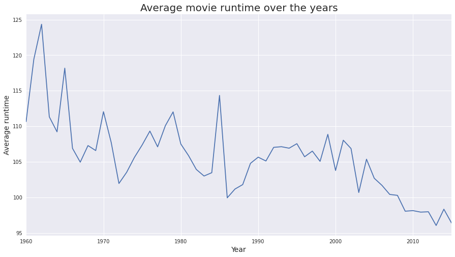

```python
# Plotting the average movies runtime over the years
df.groupby('release_year')['runtime'].mean().plot(kind='line', figsize=(15,8))
plt.title('Average movie runtime over the years', fontsize= 20)
plt.xlabel('Year', fontsize= 14)
plt.ylabel('Average runtime',fontsize= 14)
plt.show()
```

From the previous analysis and visualizations we can conclude the following:

> - The average movie runtime is generally decreasing over the years.
> - We can see that we have the lowest average movie runtime in the recent 5 years starting from 2010.

### Q4: How is the film making industry growing over the years?

```python
# Calculating the spendings, revenues and profits for each year
df.groupby('release_year')[['budget_mil','revenue_mil','profit_mil']].sum().sort_values(by= 'profit_mil', ascending= False)
```

| release_year | budget_mil | revenue_mil | profit_mil |
| --- | --- | --- | --- |
| 2014 | 24415.68 | 76738.40 | 52322.73 |
| 2015 | 22445.73 | 72157.74 | 49712.01 |
| 2013 | 22921.67 | 70889.92 | 47968.25 |
| 2012 | 20843.54 | 66245.90 | 45402.36 |
| 2009 | 19174.90 | 60872.23 | 41697.33 |
| 2011 | 18407.36 | 57385.36 | 38978.00 |
| 2008 | 17509.05 | 53059.16 | 35550.11 |
| 2010 | 18540.61 | 53266.23 | 34725.62 |
| 2007 | 15961.44 | 48383.94 | 32422.50 |
| 2006 | 15170.21 | 40855.17 | 25684.96 |
| 2005 | 13990.97 | 39160.09 | 25169.12 |
| 2004 | 12852.13 | 35846.85 | 22994.72 |
| 2003 | 12118.35 | 34288.36 | 22170.01 |
| 2002 | 10834.84 | 32369.59 | 21534.75 |
| 2001 | 10600.10 | 29635.76 | 19035.66 |
| 2000 | 10346.47 | 27253.84 | 16907.37 |
| 1999 | 10313.75 | 27065.83 | 16752.08 |
| 1997 | 9257.80 | 24258.13 | 15000.33 |
| 1998 | 9708.17 | 24669.38 | 14961.20 |
| 1996 | 8261.44 | 23064.78 | 14803.34 |
| 1994 | 6931.52 | 21602.87 | 14671.35 |
| 1995 | 7089.08 | 21734.92 | 14645.85 |
| 1993 | 5969.51 | 18555.59 | 12586.09 |
| 1989 | 4518.29 | 15991.02 | 11472.73 |
| 1992 | 4749.06 | 15315.70 | 10566.64 |
| 1990 | 4771.94 | 15200.97 | 10429.03 |
| 1977 | 1688.03 | 11643.56 | 9955.53 |
| 1991 | 5003.66 | 14787.00 | 9783.35 |
| 1988 | 4583.66 | 14261.72 | 9678.06 |
| 1987 | 3906.91 | 12744.36 | 8837.44 |
| 1973 | 1685.09 | 10384.97 | 8699.87 |
| 1984 | 3412.04 | 11517.28 | 8105.24 |
| 1982 | 2686.20 | 10274.30 | 7588.10 |
| 1986 | 3651.89 | 11153.25 | 7501.35 |
| 1978 | 2100.43 | 9297.86 | 7197.43 |
| 1985 | 3509.84 | 10663.87 | 7154.03 |
| 1981 | 2371.94 | 9090.04 | 6718.10 |
| 1979 | 1982.97 | 8515.06 | 6532.08 |
| 1980 | 2693.02 | 9168.85 | 6475.83 |
| 1967 | 1469.52 | 7815.65 | 6346.13 |
| 1975 | 1334.73 | 7217.48 | 5882.75 |
| 1974 | 1299.52 | 7046.28 | 5746.76 |
| 1983 | 2612.09 | 8274.70 | 5662.61 |
| 1971 | 1589.74 | 6899.62 | 5309.88 |
| 1965 | 1371.22 | 6623.18 | 5251.97 |
| 1976 | 1574.74 | 6637.31 | 5062.57 |
| 1972 | 1037.65 | 6032.80 | 4995.15 |
| 1964 | 1421.17 | 6310.59 | 4889.43 |
| 1970 | 1672.23 | 6369.21 | 4696.98 |
| 1961 | 1000.58 | 4880.72 | 3880.14 |
| 1966 | 1640.91 | 5288.36 | 3647.45 |
| 1968 | 1336.34 | 4767.30 | 3430.96 |
| 1969 | 1025.12 | 4442.75 | 3417.63 |
| 1962 | 1058.48 | 4201.30 | 3142.81 |
| 1963 | 1370.60 | 4442.06 | 3071.45 |
| 1960 | 1011.10 | 3946.62 | 2935.52 |

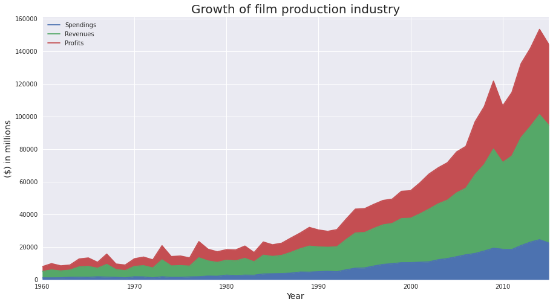

```python
# Plotting the total spendings, revenues and profits over the years
df.groupby('release_year')[['budget_mil','revenue_mil','profit_mil']].sum().plot(kind='area', figsize=(15,8));
plt.title('Growth of film production industry', fontsize= 20)
plt.xlabel('Year', fontsize= 14)
plt.ylabel('($) in millions',fontsize= 14)
plt.legend(['Spendings', 'Revenues', 'Profits'])
plt.show()
```

### Q5: What are the movies with the highest Budget, Revenue and Profit?

```python
# Calculating the top 10 highest spending movies
budget_top = df.sort_values('budget_mil', ascending= False)[['original_title', 'release_year', 'budget_mil']][:10]
budget_top
```

|  | original_title | release_year | budget_mil |
| --- | --- | --- | --- |
| 2244 | The Warrior's Way | 2010 | 425.00 |
| 3375 | Pirates of the Caribbean: On Stranger Tides | 2011 | 368.37 |
| 7387 | Pirates of the Caribbean: At World's End | 2007 | 315.50 |
| 6570 | Superman Returns | 2006 | 292.05 |
| 5231 | Titanic | 1997 | 271.69 |
| 7394 | Spider-Man 3 | 2007 | 271.33 |
| 1929 | Tangled | 2010 | 260.00 |
| 14 | Avengers: Age of Ultron | 2015 | 257.60 |
| 1389 | Harry Potter and the Half-Blood Prince | 2009 | 254.10 |
| 8089 | Waterworld | 1995 | 250.42 |

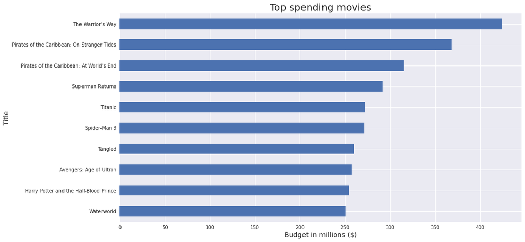

```python
# Plotting the top 10 highest spending movies
budget_top.sort_values('budget_mil', ascending= True).plot(x='original_title', y='budget_mil', kind='barh',
                                                           legend= None, figsize= (15,8));
plt.title('Top spending movies', fontsize= 20)
plt.xlabel('Budget in millions ($)', fontsize= 14)
plt.ylabel('Title',fontsize= 14)
plt.show()
```

```python
# Calculating the top 10 highest grossing movies
revenue_top = df.sort_values('revenue_mil', ascending= False)[['original_title', 'release_year', 'revenue_mil']][:10]
revenue_top
```

|  | original_title | release_year | revenue_mil |
| --- | --- | --- | --- |
| 1386 | Avatar | 2009 | 2827.12 |
| 1329 | Star Wars | 1977 | 2789.71 |
| 5231 | Titanic | 1997 | 2506.41 |
| 10594 | The Exorcist | 1973 | 2167.32 |
| 9806 | Jaws | 1975 | 1907.01 |
| 3 | Star Wars: The Force Awakens | 2015 | 1902.72 |
| 8889 | E.T. the Extra-Terrestrial | 1982 | 1791.69 |
| 8094 | The Net | 1995 | 1583.05 |
| 10110 | One Hundred and One Dalmatians | 1961 | 1574.81 |
| 4361 | The Avengers | 2012 | 1443.19 |

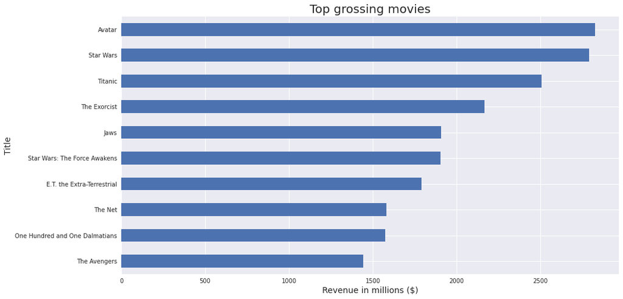

```python
# Plotting the top 10 highest grossing movies
revenue_top.sort_values('revenue_mil', ascending= True).plot(x='original_title', y='revenue_mil', kind='barh',
                                                             legend= None, figsize= (15,8));
plt.title('Top grossing movies', fontsize= 20)
plt.xlabel('Revenue in millions ($)', fontsize= 14)
plt.ylabel('Title',fontsize= 14)
plt.show()
```

```python
# Calculating the top 10 highest profitable movies
profit_top = df.sort_values('profit_mil', ascending= False)[['original_title', 'release_year', 'profit_mil']][:10]
profit_top
```

|  | original_title | release_year | profit_mil |
| --- | --- | --- | --- |
| 1329 | Star Wars | 1977 | 2750.14 |
| 1386 | Avatar | 2009 | 2586.24 |
| 5231 | Titanic | 1997 | 2234.71 |
| 10594 | The Exorcist | 1973 | 2128.04 |
| 9806 | Jaws | 1975 | 1878.64 |
| 8889 | E.T. the Extra-Terrestrial | 1982 | 1767.97 |
| 3 | Star Wars: The Force Awakens | 2015 | 1718.72 |
| 8094 | The Net | 1995 | 1551.57 |
| 10110 | One Hundred and One Dalmatians | 1961 | 1545.64 |
| 7309 | The Empire Strikes Back | 1980 | 1377.00 |

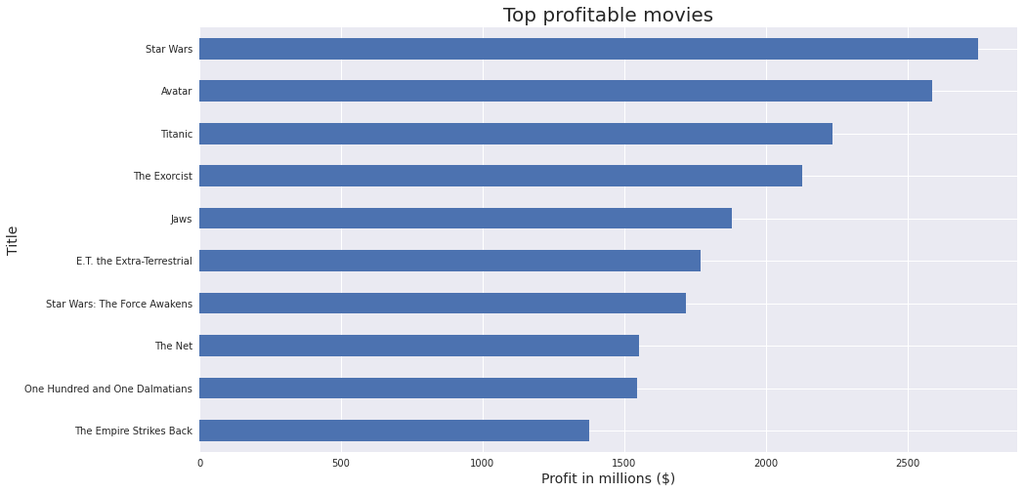

```python
# Plotting the top 10 highest profitable movies
profit_top.sort_values('profit_mil', ascending= True).plot(x='original_title', y='profit_mil', kind='barh',
                                                           legend= None, figsize= (15,8));
plt.title('Top profitable movies', fontsize= 20)
plt.xlabel('Profit in millions ($)', fontsize= 14)
plt.ylabel('Title',fontsize= 14)
plt.show()
```

From the previous analysis and visualizations we can conclude the following:

> - The top spending movie is The Warrior's Way (2010), followed by the Pirates of the Caribbean Duo.
> - The top grossing movie is Avatar (2009), followed by Star Wars and Titanic.
> - The top profitable movie is Star Wars (1977), followed by Avatar and Titanic.

### Q6: What kinds of properties are associated with movies that have high revenues?

In this section of the Analysis, We will be focusing on the properties that are associated with movies with the highest revenues.  
We will investigate the following variables effect on the revenue:

> Release Date  
> Production Company  
> Director  
> Cast  
> Genres  
> Budget  
> Rating  
> Popularity  
> Runtime

```python
# Split the Dataframe to include only movies with the highest revenues (higher than the average)
df_top_revenue = df[df.revenue_mil > df.revenue_mil.mean()]
df_top_revenue.head(3)
```

|  | id | popularity | original_title | cast | director | runtime | genres | production_companies | vote_count | vote_average | release_year | budget_mil | revenue_mil | release_month | release_day | profit_mil |
| --- | --- | --- | --- | --- | --- | --- | --- | --- | --- | --- | --- | --- | --- | --- | --- | --- |
| 0 | 135397 | 32.99 | Jurassic World | Chris Pratt\|Bryce Dallas Howard\|Irrfan Khan\|Vi... | Colin Trevorrow | 124 | Action\|Adventure\|Science Fiction\|Thriller | Universal Studios\|Amblin Entertainment\|Legenda... | 5562 | 6.5 | 2015 | 138.0 | 1392.45 | June | Tuesday | 1254.45 |
| 1 | 76341 | 28.42 | Mad Max: Fury Road | Tom Hardy\|Charlize Theron\|Hugh Keays-Byrne\|Nic... | George Miller | 120 | Action\|Adventure\|Science Fiction\|Thriller | Village Roadshow Pictures\|Kennedy Miller Produ... | 6185 | 7.1 | 2015 | 138.0 | 348.16 | May | Wednesday | 210.16 |
| 2 | 262500 | 13.11 | Insurgent | Shailene Woodley\|Theo James\|Kate Winslet\|Ansel... | Robert Schwentke | 119 | Adventure\|Science Fiction\|Thriller | Summit Entertainment\|Mandeville Films\|Red Wago... | 2480 | 6.3 | 2015 | 101.2 | 271.62 | March | Wednesday | 170.42 |

```python
# Understanding the shape of our data
df_top_revenue.shape
```

```
(1330, 16)
```

```python
# Understanding some statistical information about our data
df_top_revenue.describe()
```

|  | id | popularity | runtime | vote_count | vote_average | release_year | budget_mil | revenue_mil | profit_mil |
| --- | --- | --- | --- | --- | --- | --- | --- | --- | --- |
| count | 1330.00 | 1330.00 | 1330.00 | 1330.00 | 1330.00 | 1330.00 | 1.33e+03 | 1330.00 | 1330.00 |
| mean | 29636.78 | 1.97 | 116.07 | 1074.75 | 6.41 | 1999.34 | 7.66e+01 | 332.38 | 255.81 |
| std | 56354.00 | 2.10 | 27.20 | 1239.89 | 0.71 | 12.49 | 5.35e+01 | 276.45 | 260.21 |
| min | 11.00 | 0.02 | 69.00 | 10.00 | 4.10 | 1960.00 | 2.25e-04 | 115.23 | -36.88 |
| 25% | 1577.50 | 0.91 | 99.00 | 279.00 | 5.90 | 1993.00 | 3.69e+01 | 163.44 | 108.87 |
| 50% | 9349.00 | 1.41 | 113.00 | 617.50 | 6.40 | 2002.00 | 6.39e+01 | 233.31 | 166.59 |
| 75% | 22893.00 | 2.36 | 128.00 | 1372.75 | 6.90 | 2009.00 | 1.06e+02 | 401.05 | 313.71 |
| max | 417859.00 | 32.99 | 705.00 | 9767.00 | 8.30 | 2015.00 | 3.68e+02 | 2827.12 | 2750.14 |

```python
# Understanding the correlation between different variables
df_top_revenue.corr()
```

|  | id | popularity | runtime | vote_count | vote_average | release_year | budget_mil | revenue_mil | profit_mil |
| --- | --- | --- | --- | --- | --- | --- | --- | --- | --- |
| id | 1.00 | 0.32 | 0.06 | 0.24 | 0.04 | 0.46 | 0.03 | -0.03 | -0.03 |
| popularity | 0.32 | 1.00 | 0.14 | 0.73 | 0.33 | 0.29 | 0.31 | 0.44 | 0.41 |
| runtime | 0.06 | 0.14 | 1.00 | 0.21 | 0.34 | -0.09 | 0.21 | 0.18 | 0.15 |
| vote_count | 0.24 | 0.73 | 0.21 | 1.00 | 0.44 | 0.38 | 0.43 | 0.55 | 0.50 |
| vote_average | 0.04 | 0.33 | 0.34 | 0.44 | 1.00 | -0.16 | -0.07 | 0.28 | 0.32 |
| release_year | 0.46 | 0.29 | -0.09 | 0.38 | -0.16 | 1.00 | 0.35 | -0.05 | -0.13 |
| budget_mil | 0.03 | 0.31 | 0.21 | 0.43 | -0.07 | 0.35 | 1.00 | 0.39 | 0.21 |
| revenue_mil | -0.03 | 0.44 | 0.18 | 0.55 | 0.28 | -0.05 | 0.39 | 1.00 | 0.98 |
| profit_mil | -0.03 | 0.41 | 0.15 | 0.50 | 0.32 | -0.13 | 0.21 | 0.98 | 1.00 |

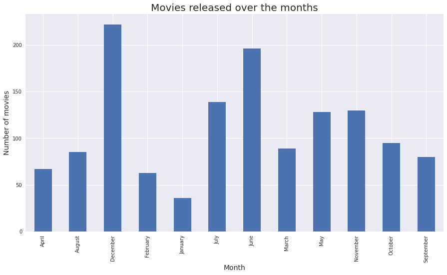

```python
# Plotting the number of movies released in each month
df_top_revenue.groupby(['release_month'])['id'].count().plot(kind='bar', figsize= (15,8));
plt.title('Movies released over the months', fontsize= 20)
plt.xlabel('Month', fontsize= 14)
plt.ylabel('Number of movies',fontsize= 14)
plt.show()
```

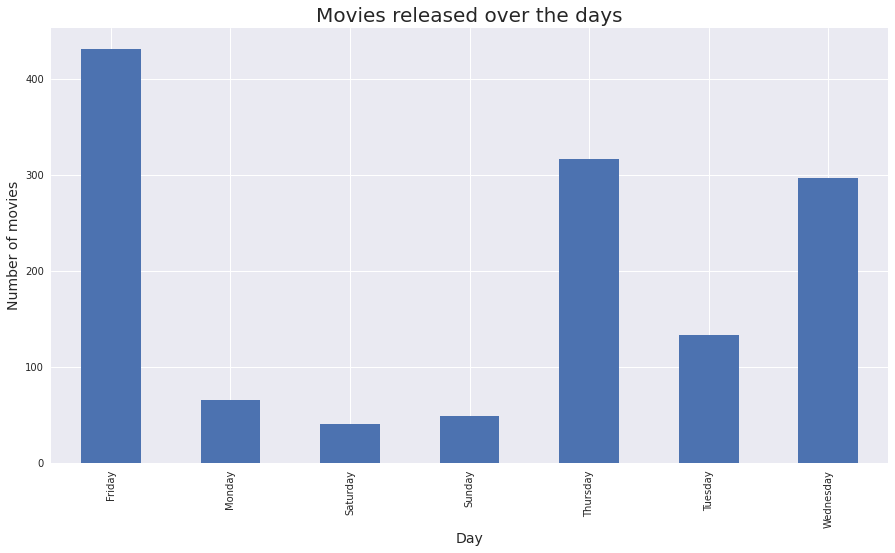

```python
# Plotting the number of movies released in each day
df_top_revenue.groupby(['release_day'])['id'].count().plot(kind='bar', figsize= (15,8));
plt.title('Movies released over the days', fontsize= 20)
plt.xlabel('Day', fontsize= 14)
plt.ylabel('Number of movies',fontsize= 14)
plt.show()
```

We can observe the following:

> - Most of the movies are usually released on December, June and july.
> - A huge number of movies are usually released on Fridays, Thursdays and Wednesdays.

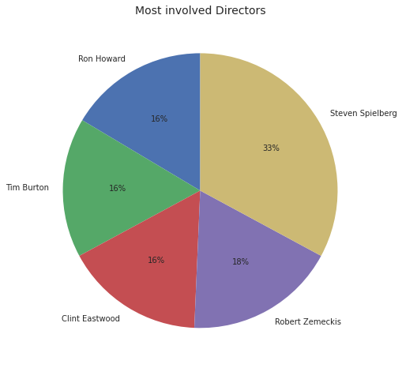

```python
# Plotting the most involved Directors in the top revenue movies
df_top_director = Split_Values(df_top_revenue, 'director')
df_top_director.director.value_counts().sort_values(ascending=True)[-5:].plot(kind='pie', label= '', startangle = 90,
                                                                              autopct='%1.0f%%', figsize=(10,8));
plt.title('Most involved Directors', fontsize= 14)
plt.show()
```

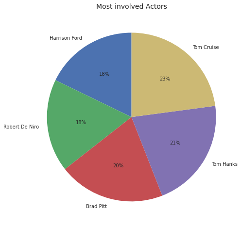

```python
# Plotting the most involved Actors in the top revenue movies
df_top_actor = Split_Values(df_top_revenue, 'cast')
df_top_actor.cast.value_counts().sort_values(ascending=True)[-5:].plot(kind='pie', label= '', startangle = 90,
                                                                       autopct='%1.0f%%', figsize=(10,8));
plt.title('Most involved Actors', fontsize= 14)
plt.show()
```

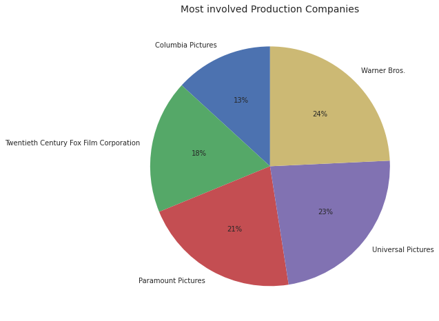

```python
# Plotting the most involved Production Companies in the top revenue movies
df_top_comp = Split_Values(df_top_revenue, 'production_companies')
df_top_comp.production_companies.value_counts().sort_values(ascending=True)[-5:].plot(kind='pie', label= '', startangle = 90,
                                                                       autopct='%1.0f%%', figsize=(10,8));
plt.title('Most involved Production Companies', fontsize= 14)
plt.show()
```

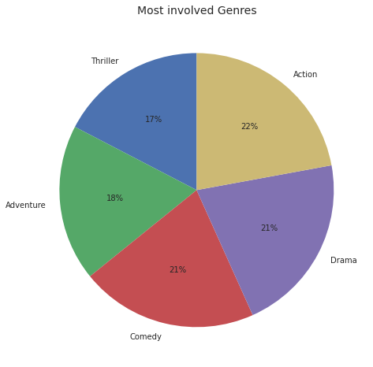

```python
# Plotting the most involved Genres in the top revenue movies
df_top_genre = Split_Values(df_top_revenue, 'genres')
df_top_genre.genres.value_counts().sort_values(ascending=True)[-5:].plot(kind='pie', label= '', startangle = 90,
                                                                       autopct='%1.0f%%', figsize=(10,8));
plt.title('Most involved Genres', fontsize= 14)
plt.show()
```

We can observe the following regarding the top revenue movies:

> - The most involved Director is Seven Spielberg, followed by Robert Zemeckis.
> - The most involved Actor is Tom Cruise, followed by Tom Hanks and Brad Pitt.
> - The most involved Production company is Warner Bros, followed by Universal Pictures and Paramount Pictures.
> - The most involved Genre is Action, followed by Drama and Comedy.

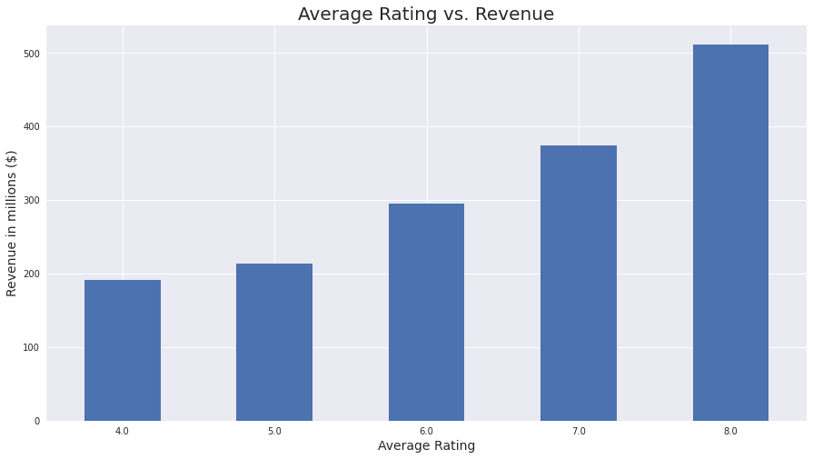

```python
# Plotting the relation between average movie rating and revenue
df_top_revenue.groupby(df_top_revenue.vote_average.round())['revenue_mil'].mean().plot(kind='bar', figsize= (15,8));
plt.title('Average Rating vs. Revenue', fontsize= 20)
plt.xlabel('Average Rating', fontsize= 14)
plt.ylabel('Revenue in millions ($)',fontsize= 14)
plt.xticks(rotation= 0)
plt.show()
```

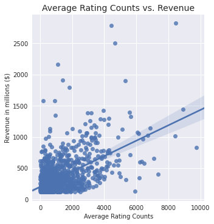

```python
# Plotting the relation between average movie rating counts and revenue
sns.lmplot(x='vote_count', y='revenue_mil', data= df_top_revenue)
plt.title('Average Rating Counts vs. Revenue', fontsize= 14)
plt.xlabel('Average Rating Counts', fontsize= 10)
plt.ylabel('Revenue in millions ($)', fontsize= 10)
plt.show()
```

We can observe the following:

> - There is a positive relation between the movie Ratings and its Revenue as higher rated movies tend to have high voting/rating counts which in turn leads to a higher revenue.

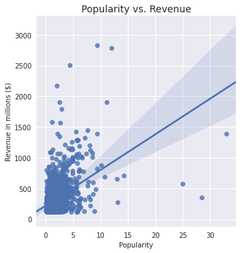

```python
# Plotting the relation between popularity and revenue
sns.lmplot(x='popularity', y='revenue_mil', data= df_top_revenue)
plt.title('Popularity vs. Revenue', fontsize= 14)
plt.xlabel('Popularity', fontsize= 10)
plt.ylabel('Revenue in millions ($)', fontsize= 10)
plt.show()
```

We can observe the following:

> - There is a positive relation between the movie Popularity and its Revenue as high popularity movies encourage more people to watch them which in turn leads to a higher revenue.

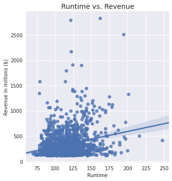

```python
# Plotting the relation between runtime and revenue
sns.lmplot(x='runtime', y='revenue_mil', data= df_top_revenue[df_top_revenue.runtime < 700])
plt.title('Runtime vs. Revenue', fontsize= 14)
plt.xlabel('Runtime', fontsize= 10)
plt.ylabel('Revenue in millions ($)', fontsize= 10)
plt.show()
```

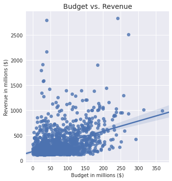

```python
# Plotting the relation between movie budget and revenue
sns.lmplot(x='budget_mil', y='revenue_mil', data= df_top_revenue)
plt.title('Budget vs. Revenue', fontsize= 14)
plt.xlabel('Budget in millions ($)', fontsize= 10)
plt.ylabel('Revenue in millions ($)', fontsize= 10)
plt.show()
```

We can observe the following:

> - There is a positive relation between the movie Budget and its Revenue as higher spending in production phase improves the movie quality which in turn leads to a higher revenue.

## Conclusions

Finally, reaching the end of the analysis, we can now summarize our findings and the results that have been concluded in relation to the question(s) provided at the beginning of the analysis in the following points:

**Q1: Which genres are most popular from year to year?**

> - Popularity of different genres is increasing over time in general, However, the top popular genres for each year are nearly the same; people tend to prefer **Drama, Comedy, Action, Thriller, and Adventure.**
> - **Drama** with total popularity of **2815** is the most popular genre of all time followed by **Comedy**, **Action** and **Thriller** with total popularity of **2247**, **2208** and **2155** respectively.

**Q3: How does the movies runtime change over the years?**

> - The average movie runtime is generally decreasing over the years.
> - We can see that we have the lowest average movie runtime in the recent 5 years starting from **2010** averaging about **97 minutes** only.

>   > Part of the reason we could be seeing shorter movies is that studios are trying to boost ticket sales. *“The old conventional wisdom about shorter movies is that you can have more showings in a day”* as said by Paul Dergarabedian, Senior Media Analyst at comScore.

**Q4: How is the film making industry growing over the years?**

> - The film production industry is generally growing over the years in both aspects; movies budgets and revenues.
> - We can see that the total profits is increasing massively (Almost tripled!) in the recent 15 years starting from **2000** at which the total profits were about **17 Billions Dollars** reaching about **50 Billions Dollars** in **2015**!.

**Q5: What are the movies with the highest Budget, Revenue and Profit?**

> - The top spending movie is **The Warrior's Way (2010)** with a massive budget of **425 Million Dollars!**, followed by the **Pirates of the Caribbean** Duo with a budget of **368 and 315 Million Dollars** respectively.
> - The top grossing movie is **Avatar (2009)** with a revenue of **2.83 Billion Dollars**, followed by **Star Wars** and **Titanic** with a revenue of **2.79** and **2.51 Billion Dollars** respectively.
> - The top profitable movie is **Star Wars (1977)** with a profit of **2.75 Billion Dollars**, followed by **Avatar** and **Titanic** with a profit of **2.59** and **2.23 Billion Dollars** respectively.

**Q6: What kinds of properties are associated with movies that have high revenues?**

**A quick reminder**: To answer this question, we are working with the Data of the movies only with the highest revenues. (higher than the average)

1- Release Date:

> - Most of the top revenue movies are usually released on **December**, **June** and **july**.
> - A huge number of movies are usually released on **Fridays**, **Thursdays** and **Wednesdays**.

>   > Top Revenue movies are usually released on Fridays/ Thursday nights. By this it is easier for people to make time to see them during the weekend, also when Thursdays happen to be a holiday, some movies comes out on Wednesday for the same reason.

2- Genre, Director, Cast and Production Company:

> - The most involved Genre is **Action**, followed by **Drama** and **Comedy**.
> - The most involved Director is **Seven Spielberg**, followed by **Robert Zemeckis**.
> - The most involved Actor is **Tom Cruise**, followed by **Tom Hanks** and **Brad Pitt**.
> - The most involved Production company is **Warner Bros***, followed by **Universal Pictures** and **Paramount Pictures**.

>   > The above information gives us some insights that some genres tends to attract more revenues than others, also the movie Director, Cast, and Production Company play a great role in the popularity and revenue of the movie as all these factors improves the movie quality.

3- Budget:

> - There is a **positive** relation between the movie Budget and its Revenue as higher spending in production phase (spending on the Best Directors, Actors and Production Companies) improves the movie quality which in turn leads to a higher revenue.

4- Popularity & Rating:

> - There is a **positive** relation between the movie Popularity and Rating and its Revenue as high popularity movies generate a buzz by a whole bunch of people going to the theater to see the movie so it draws more people to see the movie. Today, with social media, it's even more important to get as many people talking about a movie (good or bad) at once to populate the newsfeeds with reminders to go watch it, making it having high voting/rating counts Hince, getting higher Ratings which in turn leads to a higher revenue.

### Limitations

There are some limitations in the Data that certainly impacted our Analysis which can be listed below:

> 1- The Budget and Revenue columns contain more than 50% zero values!.  
> 2- The popularity column values are not clear; how it is calulated or what criteria it is based on.  
> 3- The Cast, Director, Genres, and Specially the Production Companies columns contain a lot of missing values which can affect the Analysis.  
> 4- The Data contains a lot of irrelevant columns with a lot of missing values such as Homepage, Tagline, Keywords and Overview columns.  
> 5- Some columns of the Data contain outliers such as: Runtime, Budget and Revenue.

### Thank You.

```python
from subprocess import call
call(['python', '-m', 'nbconvert', 'Investigate_a_Dataset.ipynb'])
```

```
0
```